# Personalized Grit Lab Report

Hi Kaylee,

Welcome to your personalized Grit Lab report!

We will go week by week, reviewing everything you have told us through Poll Everywhere.

We hope this will help you reflect on what you learned and experienced during Grit Lab.

Do you rememeber the grit rubric, from the first time we met?

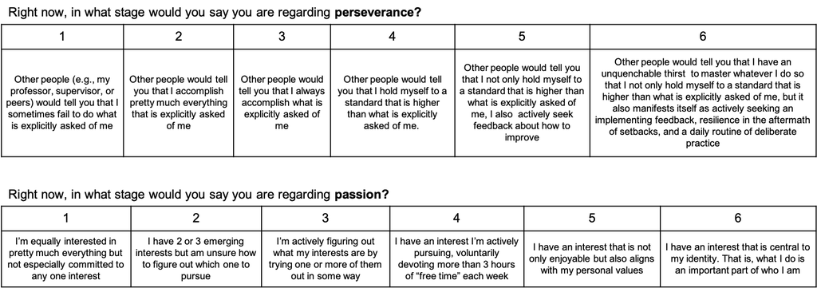

- You rated your **passion** as Stage 2: I have 2 or 3 emerging interests but am unsure how to figure out which one to pursue
- ...and your **perseverance** as Stage 4: Other people would tell you that I hold myself to a standard that is higher than what is explicitly asked of me.

Here's a graph:

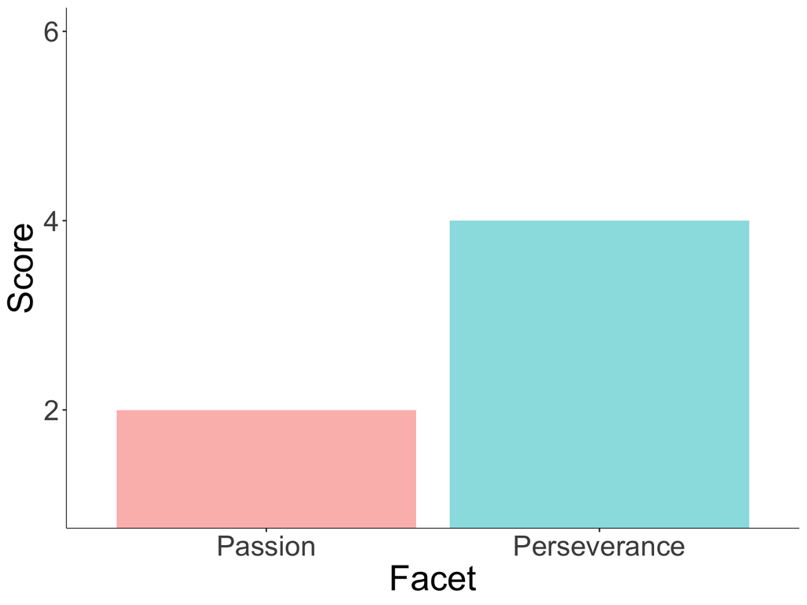

Then, you learned about goal setting, planning, and deliberate practice.

You established a wish, imagined its associated outcome, identified potential personal obstacles, and then planned accordingly, using implementation intentions.

Did it go according to plan?

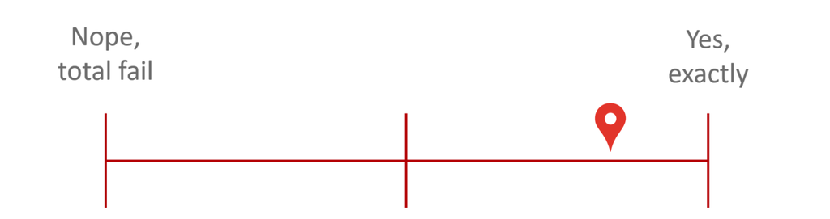

And here is how much you learned

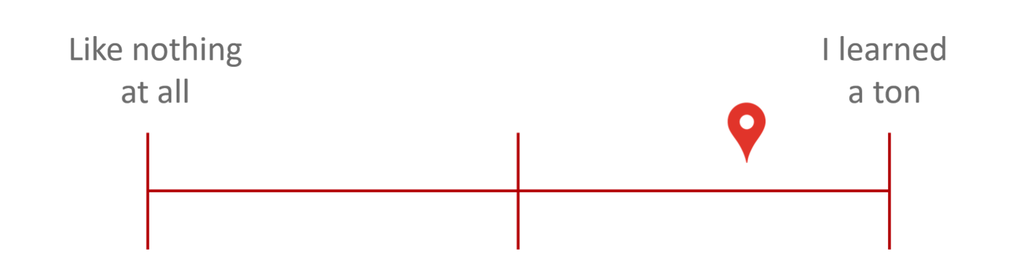

In week four, we discussed **feedback.**

You told us that you felt offended when receiving negative feedback,

...and validated when recieveing positive feedback.

We then turned to learning about **stress.**

In week 5, you reported feeling nearly an extreme amount of stress in your life right now, the primary source of it being friendships.

We also talked about **adversity and failure.**

Although related, adversity and failure are different:

Adversity happens to us, whereas failure is something for which we are generally more responsible.

Perhaps that is why you said that failure had made you feel worthless.

However, how we interpret stress and failure matters...

...and that it is true that stress facilitates learning and growth.

Interestingly, research has found that people who believe that stress can facilitate learning and growth experience enhanced **performance, well-being and health.**

On week six, we talked about mentors

...you said for you, your most important mentor was teacher or professor.

Here's how you described him or her:

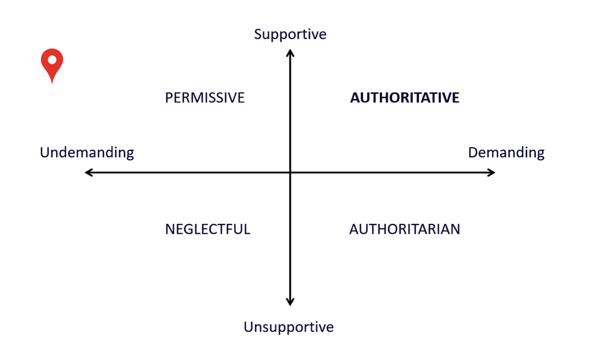

You also wrote a gratitude letter to my mom or dad. Do you remember what you said and how it made you feel?

On week eight, we talked about **interest.**

We talked about states of extreme interest, or as Mihaly Csikszentmihalyi would call it, flow.

You said you had experienced flow when watching netflix.

How do you feel when you are watching netflix and get into the flow state?

We then transitioned into **values**.

There, you said you preferred to gain wealth/status, have approval from others and be spontaneous.

These responses, in a sense, spoke about what you valued.

You wrote a *This I Believe* essay, and located it here in Schwartz's value circle:

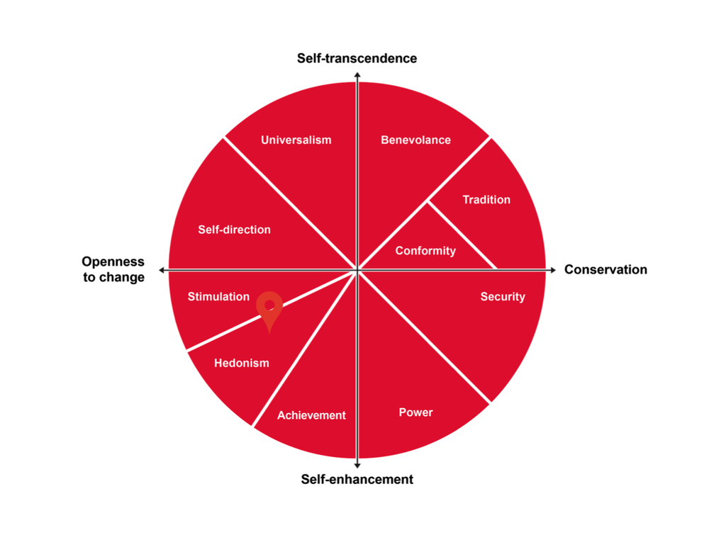

For **strengths,** Danny gave us an interesting lecture on the nature of talent.

You defined talent as specialty.

You ranked your top three talents as: Analytic, Social, and Artistic / Spatial.

You said your personality strength was Agreeableness.

We then examined **demand and social impact.** Here's how you said you cared about salary vs. social impact for your first career move:

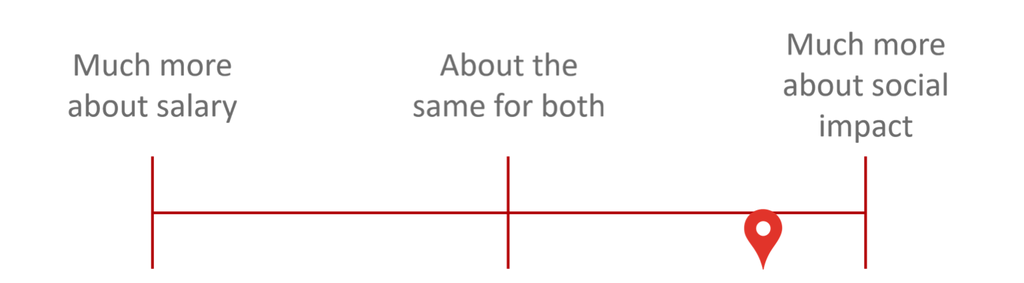

We also asked why you worked hard.

You said you neither agree nor disagree to working hard for wanting to help others,

...and you agree with working hard because you enjoy it.

Regarding demand, you said the most serious issues affecting your country were:

Inequality (income/discrimination).

Loss of privacy due to technology.

Climate change.

Would you like to work towards these?

We then talked about **goal hierarchies,** which require you to have a top-level goal. How clear is your top-level goal? You said: I have a pretty good idea.

Over time and with self-reflection, this will get clearer and clearer.

One particular goal you have for the next six months is to working on my mental and physical health.

You rated that goal in terms of how much it really represents you. Here’s what you said:

Red bars represent self-concordant motivation, while blue bars represent non-concordant motivation.

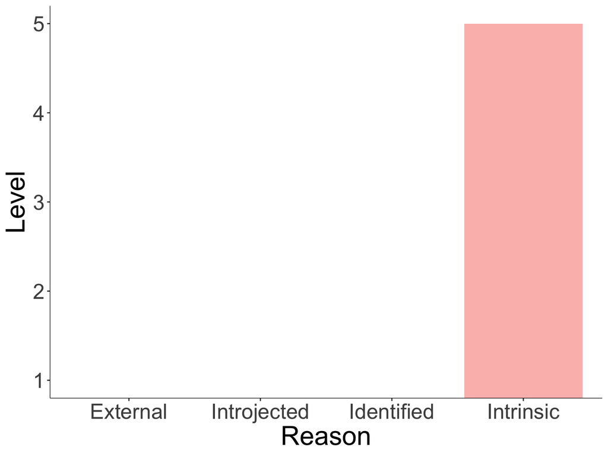

Finally, on the penultimate lecture we looked at paying it forward.

We learned about reciprocity style: givers, takers, and matchers. You also responded to items about prosocial purpose.

Here are your responses to items surveying this:

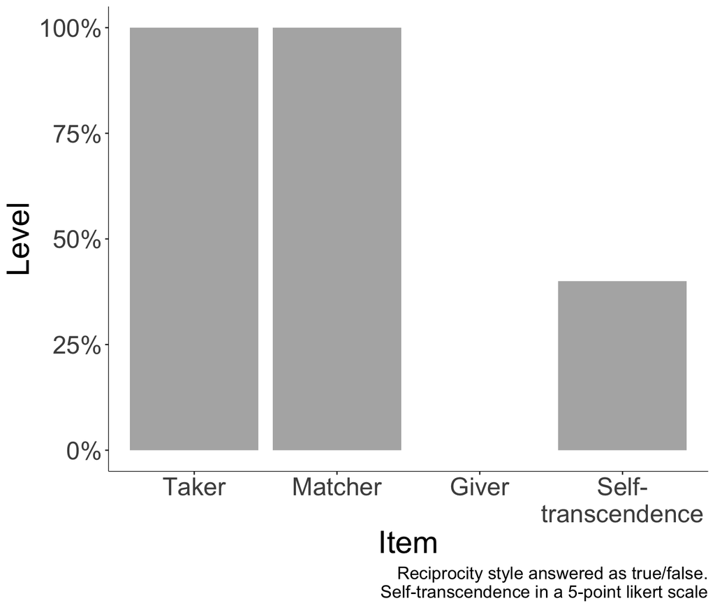

Remember your mood meter?

Here's how your mood evolved through the semester

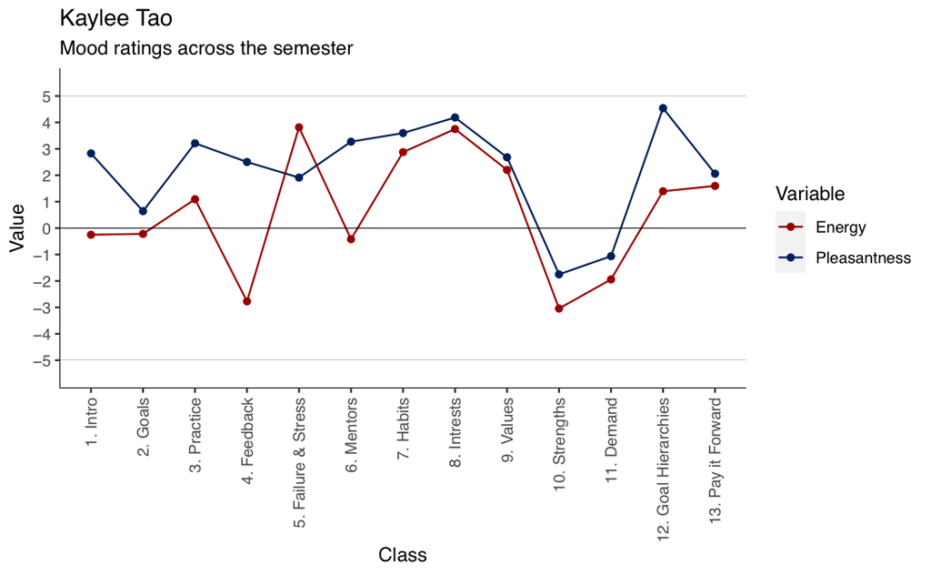

After all this time, we hope you have emerged from Grit Lab a little grittier than you started.

Do you want to see how your grit rubric changed?

Drumroll please...

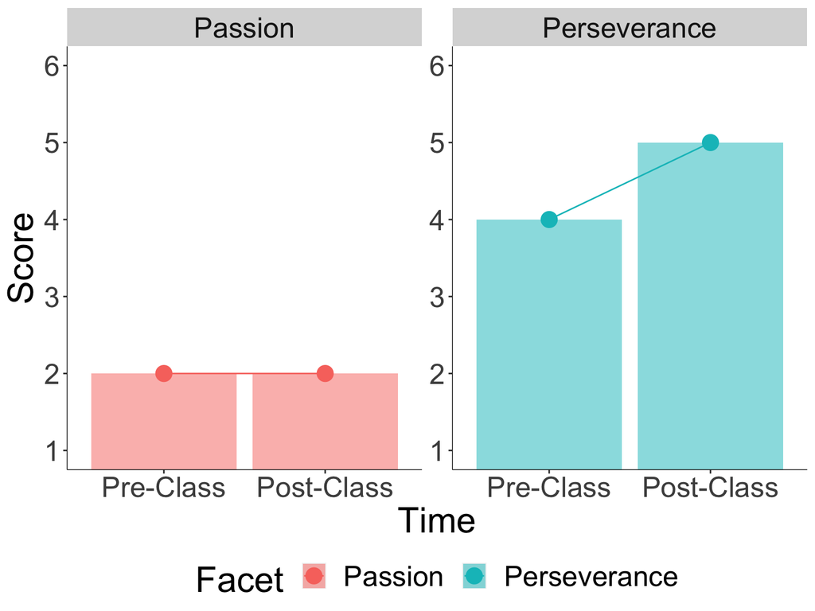

Don't worry if the rubric doesn't yet reflect growth. It is only a coarse measure that cannot replace your own self-reflection.

In any case, grit is not built in a day...

...so stay passionate and persevering on the lifelong quest of choosing easy, working hard, and paying it forward.

With grit and gratitude,

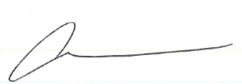

Angela and the Grit Lab team.